# Explainability

2024-01-25

# Understanding distributions

```r
data <- read_csv('train.csv')
```

```
## ──────────────────────────────────────────────────────── Delimiter: "," chr
## (4): home_team_name, away_team_name, home_formation, away_fromation dbl (59):
## ...1, HomePlayer_Overall_max, HomePlayer_Overall_min, HomePlayer_O...
```

```r
glimpse(data)
```

```
## Rows: 3,040
## Columns: 63
## $ ...1                              <dbl> 0, 1, 2, 3, 4, 5, 6, 7, 8, 9, 10, 11…
## $ HomePlayer_Overall_max            <dbl> 86, 87, 89, 83, 80, 81, 81, 79, 76, …
## $ HomePlayer_Overall_min            <dbl> 66, 74, 64, 63, 60, 73, 71, 72, 69, …
## $ HomePlayer_Overall_sd             <dbl> 7.785768, 4.006812, 6.983096, 5.3069…
## $ HomePlayer_Overall_median         <dbl> 80, 81, 82, 80, 76, 77, 76, 77, 73, …
## $ HomePlayer_bench_Overall_mean     <dbl> 75.28571, 76.00000, 71.42857, 76.428…
## $ HomePlayer_Overall_mean           <dbl> 78.27273, 81.63636, 80.81818, 78.181…
## $ HomePlayer_bench_Overall_max      <dbl> 81, 82, 89, 79, 79, 78, 80, 77, 77, …
## $ HomePlayer_bench_Overall_min      <dbl> 63, 55, 55, 74, 60, 67, 61, 58, 66, …
## $ HomePlayer_bench_Overall_sd       <dbl> 7.609518, 9.469248, 12.946777, 1.618…
## $ HomePlayer_bench_Overall_median   <dbl> 80, 81, 82, 80, 76, 77, 76, 77, 73, …
## $ AwayPlayer_Overall_max            <dbl> 74, 77, 76, 76, 85, 79, 79, 87, 79, …
## $ AwayPlayer_Overall_min            <dbl> 69, 62, 70, 68, 74, 71, 72, 67, 58, …
```

[output cut: 50 more lines]

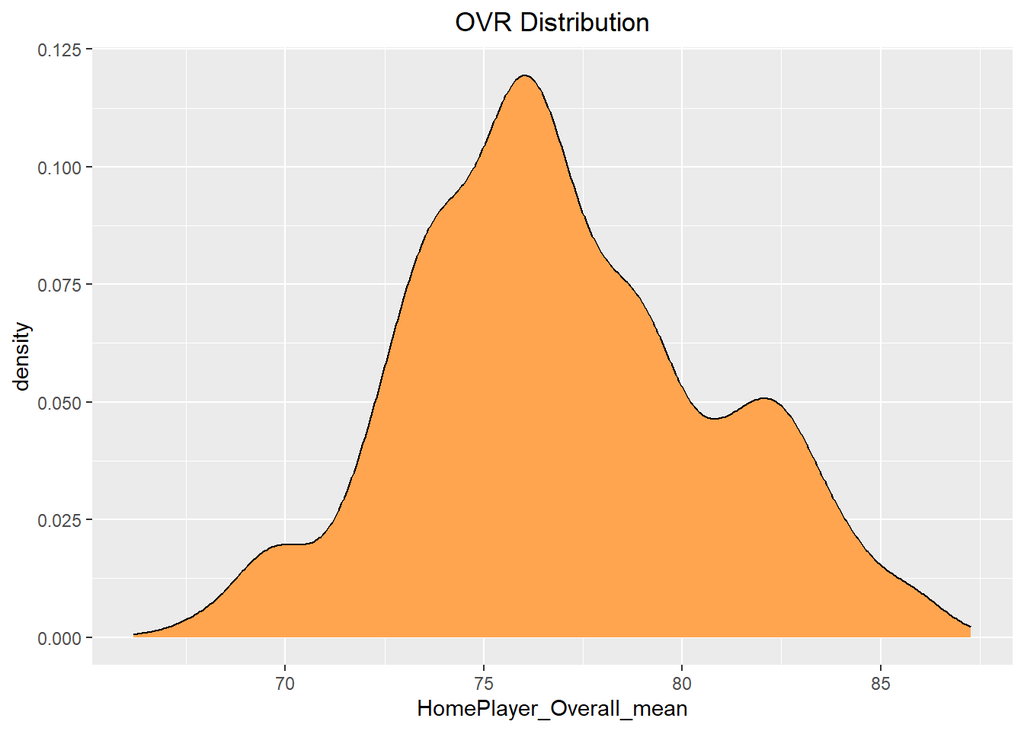

```r
ggplot(data=data, aes(x=HomePlayer_Overall_mean)) +
  geom_density(fill="tan1") + labs(title="OVR Distribution", xlab="Age") + theme(plot.title = element_text(hjust = 0.5))
```

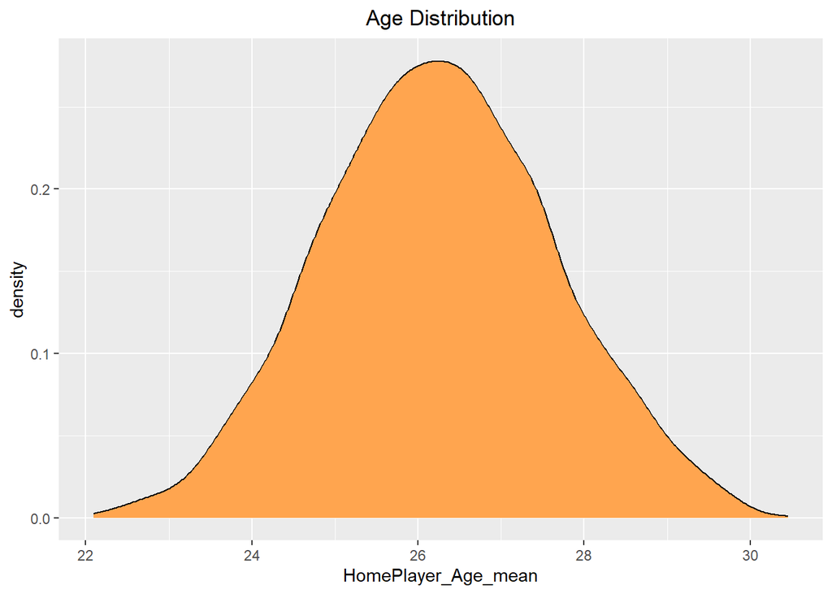

```r
ggplot(data=data, aes(x=HomePlayer_Age_mean)) +
  geom_density(fill="tan1") + labs(title="Age Distribution", xlab="Age") + theme(plot.title = element_text(hjust = 0.5))
```

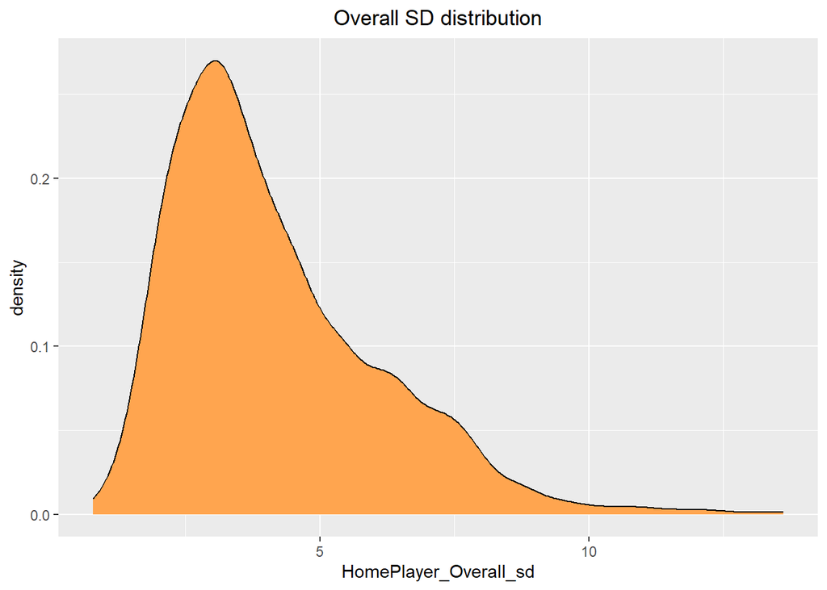

```r
ggplot(data=data, aes(x=HomePlayer_Overall_sd)) +
  geom_density(fill="tan1") + labs(title="Overall SD distribution", xlab="Age") + theme(plot.title = element_text(hjust = 0.5))
```

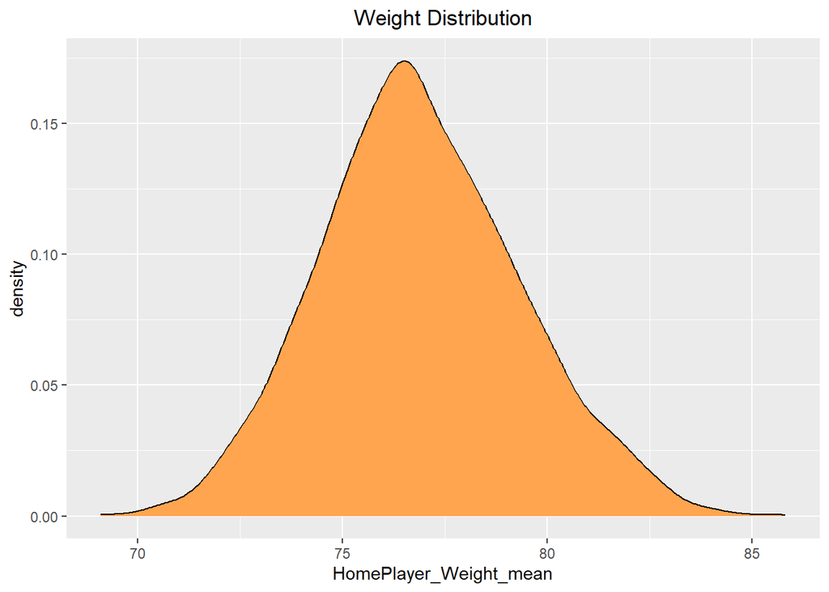

```r
ggplot(data=data, aes(x=HomePlayer_Weight_mean)) +
  geom_density(fill="tan1") + labs(title="Weight Distribution", xlab="Age") + theme(plot.title = element_text(hjust = 0.5))
```

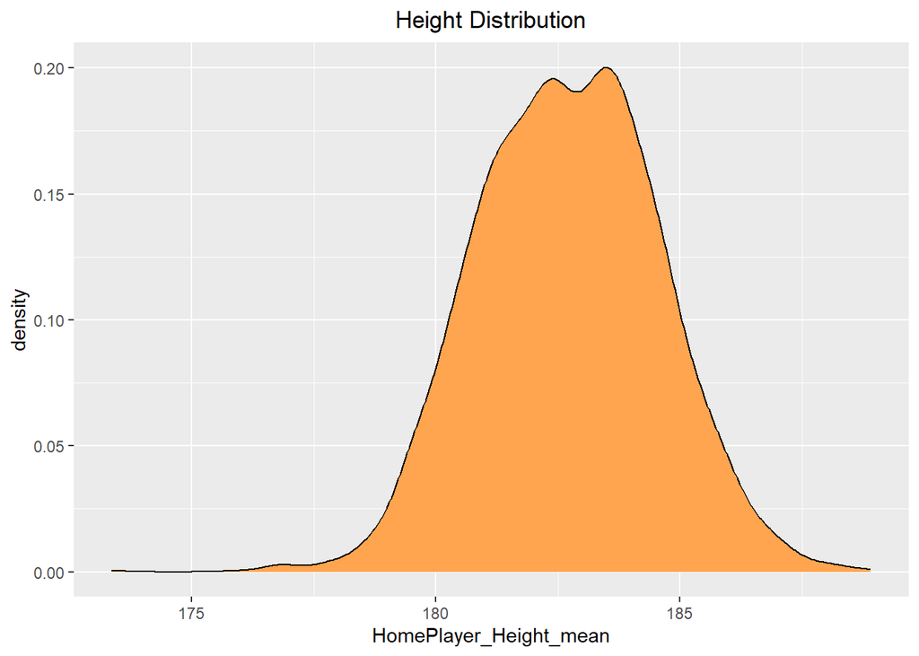

```r
ggplot(data=data, aes(x=HomePlayer_Height_mean)) +
  geom_density(fill="tan1") + labs(title="Height Distribution", xlab="Age") + theme(plot.title = element_text(hjust = 0.5))
```

What we can see is that mean values distributions are close to normal and the sd reminds us of the Xi^2 Distribution

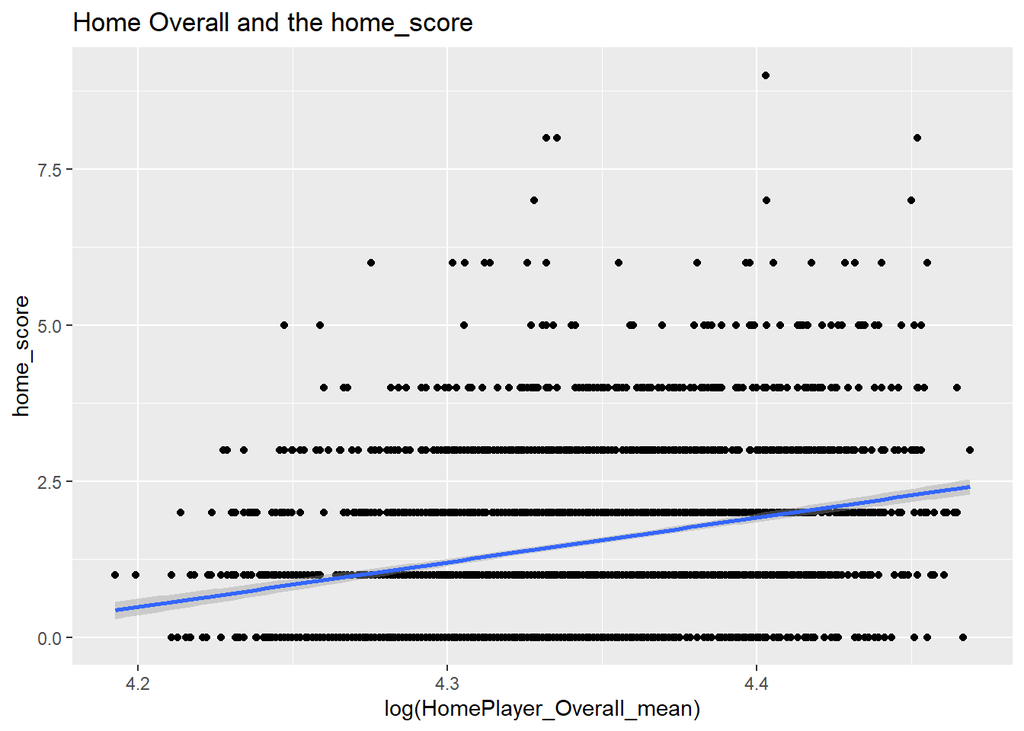

```r
ggplot(data = data, aes(x = log(HomePlayer_Overall_mean),
                       y = home_score)) +
  geom_point() + stat_smooth(method = "lm") +
  ggtitle("Home Overall and the home_score")
```

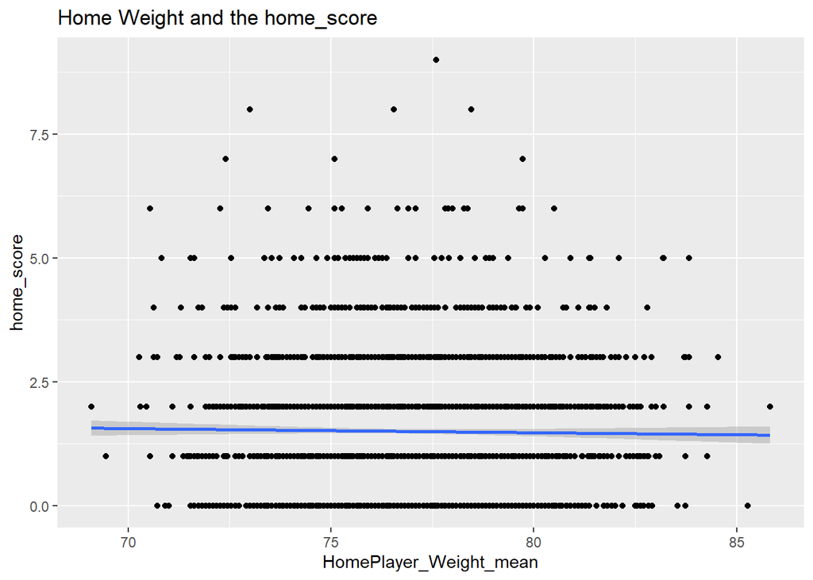

```r
ggplot(data = data, aes(x = HomePlayer_Weight_mean,
                       y = home_score)) +
  geom_point() + stat_smooth(method = "lm") +
  ggtitle("Home Weight and the home_score")
```

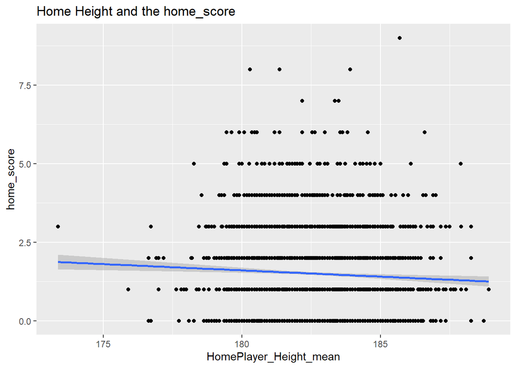

```r
ggplot(data = data, aes(x = HomePlayer_Height_mean,
                       y = home_score)) +
  geom_point() + stat_smooth(method = "lm") +
  ggtitle("Home Height and the home_score")
```

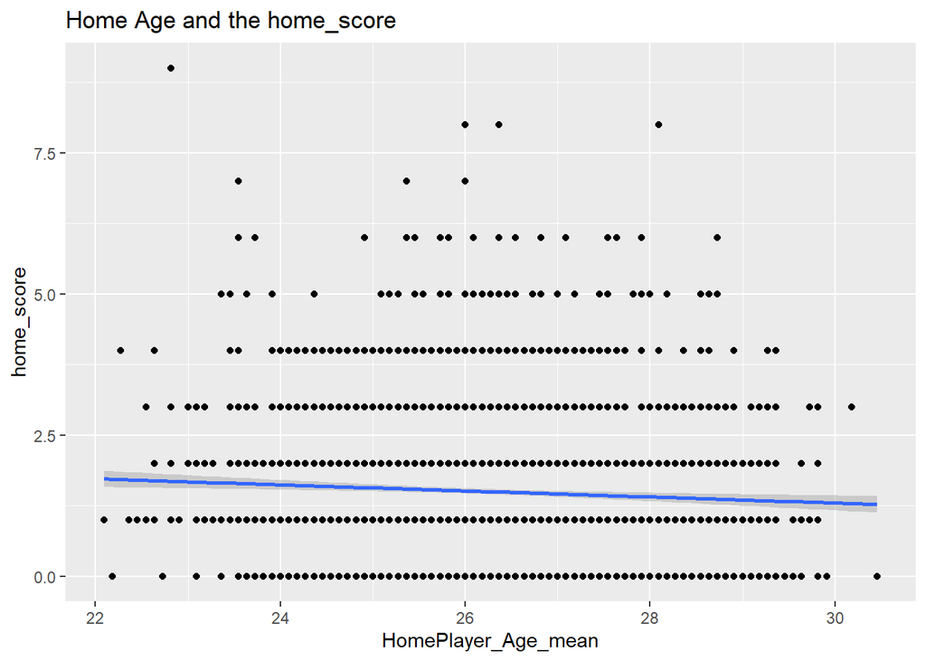

```r
ggplot(data = data, aes(x = HomePlayer_Age_mean,
                       y = home_score)) +
  geom_point() + stat_smooth(method = "lm") +
  ggtitle("Home Age and the home_score")
```

We can see only for the average rating of the starting 11, that it has positive effect, and for the others its pretty close to even 0.

Why is it?

Maybe because for some areas of the age, raising the average could be beneficial, for example: A team who is full of very young and inexperienced players could be worse than a team full of 26-30 year old players. It could also be true for both height and weight. Weight is self explanatory, but height could give us the idea, that for example there is connection between player height and speed / agility.

How can we show it?

Maybe we can try when running our models, keep in mind adding a squared version of height weight and age

```r
summary(data$HomePlayer_Overall_mean)
```

```
##    Min. 1st Qu.  Median    Mean 3rd Qu.    Max.
##   66.18   74.27   76.45   76.94   79.36   87.27
```

```r
summary(data$HomePlayer_Overall_min)
```

```
##    Min. 1st Qu.  Median    Mean 3rd Qu.    Max.
##   50.00   64.75   70.00   68.62   73.00   84.00
```

```r
summary(data$HomePlayer_Overall_max)
```

```
##    Min. 1st Qu.  Median    Mean 3rd Qu.    Max.
##   72.00   79.00   82.00   82.38   86.00   91.00
```

```r
summary(data$HomePlayer_Overall_sd)
```

```
##    Min. 1st Qu.  Median    Mean 3rd Qu.    Max.
##  0.7746  2.7336  3.6730  4.1482  5.2333 13.6174
```

```r
summary(data$AwayPlayer_Overall_mean)
```

```
##    Min. 1st Qu.  Median    Mean 3rd Qu.    Max.
##   66.18   74.27   76.45   76.89   79.27   87.73
```

```r
summary(data$AwayPlayer_Overall_min)
```

```
##    Min. 1st Qu.  Median    Mean 3rd Qu.    Max.
##   50.00   64.00   70.00   68.58   73.00   84.00
```

```r
summary(data$AwayPlayer_Overall_max)
```

```
##    Min. 1st Qu.  Median    Mean 3rd Qu.    Max.
##   72.00   79.00   82.00   82.34   86.00   91.00
```

```r
summary(data$AwayPlayer_Overall_sd)
```

```
##    Min. 1st Qu.  Median    Mean 3rd Qu.    Max.
##  0.7379  2.7236  3.6666  4.1424  5.2064 12.8910
```

```r
lm_model <- lm(data=data, formula = home_score ~
                 HomePlayer_Overall_mean +
                 HomePlayer_Overall_min +
                 HomePlayer_Overall_max +
                 HomePlayer_Overall_sd +
                 HomePlayer_Height_mean + I(HomePlayer_Height_mean^2)  +
                 HomePlayer_Weight_mean + I(HomePlayer_Weight_mean^2)  +

                 HomePlayer_Age_mean + I(HomePlayer_Age_mean^2)+
               + home_team_name+ away_team_name)

summary(lm_model)
```

```
##
## Call:
## lm(formula = home_score ~ HomePlayer_Overall_mean + HomePlayer_Overall_min +
##     HomePlayer_Overall_max + HomePlayer_Overall_sd + HomePlayer_Height_mean +
##     I(HomePlayer_Height_mean^2) + HomePlayer_Weight_mean + I(HomePlayer_Weight_mean^2) +
##     HomePlayer_Age_mean + I(HomePlayer_Age_mean^2) + +home_team_name +
##     away_team_name, data = data)
##
## Residuals:
##     Min      1Q  Median      3Q     Max
## -2.7556 -0.8764 -0.1332  0.6998  7.0355
##
## Coefficients:
##                                         Estimate Std. Error t value Pr(>|t|)
## (Intercept)                            1.416e+01  1.621e+02   0.087 0.930386
## HomePlayer_Overall_mean                5.585e-02  2.157e-02   2.589 0.009661
## HomePlayer_Overall_min                -1.164e-02  1.327e-02  -0.877 0.380504
## HomePlayer_Overall_max                 4.024e-03  2.244e-02   0.179 0.857693
## HomePlayer_Overall_sd                 -2.030e-02  4.593e-02  -0.442 0.658548
## HomePlayer_Height_mean                -1.189e-01  1.824e+00  -0.065 0.948003
## I(HomePlayer_Height_mean^2)            3.962e-04  4.994e-03   0.079 0.936777
## HomePlayer_Weight_mean                -1.396e-01  4.715e-01  -0.296 0.767241
## I(HomePlayer_Weight_mean^2)            8.958e-04  3.057e-03   0.293 0.769554
## HomePlayer_Age_mean                   -1.072e-01  4.905e-01  -0.219 0.826958
## I(HomePlayer_Age_mean^2)               1.394e-03  9.311e-03   0.150 0.881028
## home_team_nameArsenal                  9.492e-02  1.932e-01   0.491 0.623290
## home_team_nameAston Villa             -3.787e-01  1.797e-01  -2.107 0.035169
## home_team_nameBrentford               -3.547e-01  3.138e-01  -1.130 0.258409
## home_team_nameBrighton & Hove Albion  -5.282e-01  1.972e-01  -2.678 0.007441
## home_team_nameBurnley                 -4.913e-01  1.783e-01  -2.755 0.005899
## home_team_nameCardiff City            -2.979e-01  3.116e-01  -0.956 0.339214
## home_team_nameChelsea                  1.204e-02  2.106e-01   0.057 0.954420
## home_team_nameCrystal Palace          -4.674e-01  1.789e-01  -2.613 0.009025
## home_team_nameEverton                 -1.515e-01  1.789e-01  -0.847 0.396915
## home_team_nameFulham                  -7.101e-01  2.461e-01  -2.885 0.003940
## home_team_nameHuddersfield Town       -1.018e+00  3.134e-01  -3.248 0.001174
## home_team_nameHull City               -2.208e-01  2.165e-01  -1.020 0.307833
## home_team_nameLeeds United            -2.721e-01  2.411e-01  -1.129 0.259163
## home_team_nameLeicester City           7.400e-02  1.755e-01   0.422 0.673319
## home_team_nameLiverpool                2.482e-01  2.011e-01   1.234 0.217180
```

[output cut: 112 more lines]

```
## away_team_nameSouthampton             **
## away_team_nameStoke City              **
## away_team_nameSunderland
## away_team_nameSwansea City            .
## away_team_nameTottenham Hotspur       ***
## away_team_nameWatford
## away_team_nameWest Bromwich Albion    **
## away_team_nameWest Ham United         **
## away_team_nameWolverhampton Wanderers ***
## ---
## Signif. codes:  0 '***' 0.001 '**' 0.01 '*' 0.05 '.' 0.1 ' ' 1
##
## Residual standard error: 1.196 on 2967 degrees of freedom
## Multiple R-squared:  0.1586, Adjusted R-squared:  0.1382
## F-statistic:  7.77 on 72 and 2967 DF,  p-value: < 2.2e-16
```

```r
data <- data%>%
  mutate(GD = home_score-away_score)
lm_model <- felm(data=data, formula = home_score ~
                 HomePlayer_Overall_mean +
                 HomePlayer_Overall_min +
                 HomePlayer_Overall_max +
                 HomePlayer_Overall_sd + I(HomePlayer_Overall_sd^2)+

                 AwayPlayer_Overall_mean +
                 AwayPlayer_Overall_min +
                 AwayPlayer_Overall_max +
                 AwayPlayer_Overall_sd +

                 HomePlayer_Height_mean + I(HomePlayer_Height_mean^2)  +
                 AwayPlayer_Height_mean + I(AwayPlayer_Height_mean^2)  +
                 HomePlayer_Weight_mean + I(HomePlayer_Weight_mean^2)  +
                 AwayPlayer_Weight_mean + I(AwayPlayer_Weight_mean^2)  +

                 HomePlayer_Age_mean + I(HomePlayer_Age_mean^2)+
                 AwayPlayer_Age_mean + I(AwayPlayer_Age_mean^2)
               | home_team_name+away_team_name | 0 | 0)

summary(lm_model)
```

```
##
## Call:
##    felm(formula = home_score ~ HomePlayer_Overall_mean + HomePlayer_Overall_min +      HomePlayer_Overall_max + HomePlayer_Overall_sd + I(HomePlayer_Overall_sd^2) +      AwayPlayer_Overall_mean + AwayPlayer_Overall_min + AwayPlayer_Overall_max +      AwayPlayer_Overall_sd + HomePlayer_Height_mean…
##
## Residuals:
##     Min      1Q  Median      3Q     Max
## -2.8881 -0.8755 -0.1259  0.7007  6.7727
##
## Coefficients:
##                               Estimate Std. Error t value Pr(>|t|)
## HomePlayer_Overall_mean      6.553e-02  2.191e-02   2.991  0.00281 **
## HomePlayer_Overall_min      -8.650e-03  1.444e-02  -0.599  0.54910
## HomePlayer_Overall_max       8.004e-04  2.313e-02   0.035  0.97240
## HomePlayer_Overall_sd        1.679e-02  8.032e-02   0.209  0.83448
## I(HomePlayer_Overall_sd^2)  -3.213e-03  4.503e-03  -0.714  0.47553
## AwayPlayer_Overall_mean     -1.491e-02  2.188e-02  -0.681  0.49578
## AwayPlayer_Overall_min       1.835e-02  1.323e-02   1.387  0.16569
## AwayPlayer_Overall_max      -2.849e-02  2.243e-02  -1.270  0.20410
## AwayPlayer_Overall_sd        6.767e-02  4.637e-02   1.459  0.14455
## HomePlayer_Height_mean       2.965e-02  1.824e+00   0.016  0.98703
## I(HomePlayer_Height_mean^2)  9.749e-07  4.995e-03   0.000  0.99984
## AwayPlayer_Height_mean      -2.980e+00  1.822e+00  -1.636  0.10194
## I(AwayPlayer_Height_mean^2)  8.121e-03  4.987e-03   1.628  0.10353
## HomePlayer_Weight_mean      -2.187e-02  4.734e-01  -0.046  0.96315
## I(HomePlayer_Weight_mean^2)  1.218e-04  3.070e-03   0.040  0.96836
## AwayPlayer_Weight_mean      -7.920e-01  4.579e-01  -1.730  0.08378 .
## I(AwayPlayer_Weight_mean^2)  5.101e-03  2.964e-03   1.721  0.08535 .
## HomePlayer_Age_mean         -9.035e-03  4.927e-01  -0.018  0.98537
## I(HomePlayer_Age_mean^2)    -6.793e-04  9.353e-03  -0.073  0.94211
## AwayPlayer_Age_mean         -4.380e-01  4.858e-01  -0.902  0.36734
## I(AwayPlayer_Age_mean^2)     9.129e-03  9.221e-03   0.990  0.32222
## ---
## Signif. codes:  0 '***' 0.001 '**' 0.01 '*' 0.05 '.' 0.1 ' ' 1
##
## Residual standard error: 1.194 on 2956 degrees of freedom
## Multiple R-squared(full model): 0.1644   Adjusted R-squared: 0.141
## Multiple R-squared(proj model): 0.01374   Adjusted R-squared: -0.01395
## F-statistic(full model):7.008 on 83 and 2956 DF, p-value: < 2.2e-16
## F-statistic(proj model): 1.961 on 21 and 2956 DF, p-value: 0.005553
```

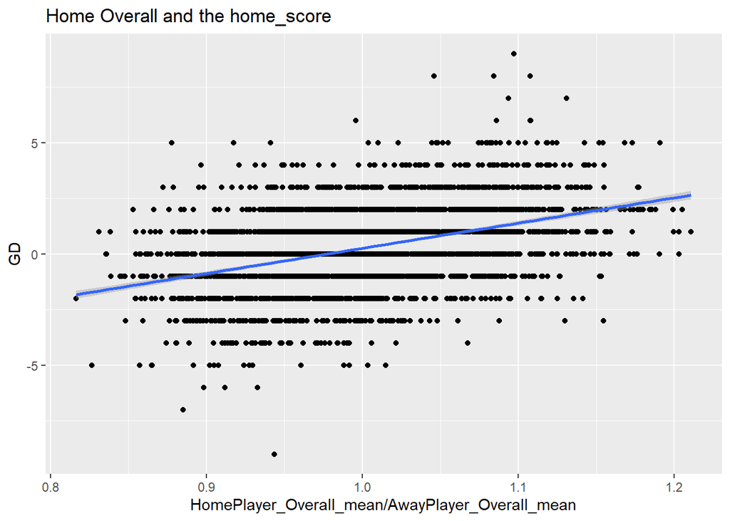

```r
ggplot(data = data, aes(x = HomePlayer_Overall_mean/AwayPlayer_Overall_mean,
                       y = GD)) +
  geom_point() + stat_smooth(method = "lm") +
  ggtitle("Home Overall and the home_score")
```

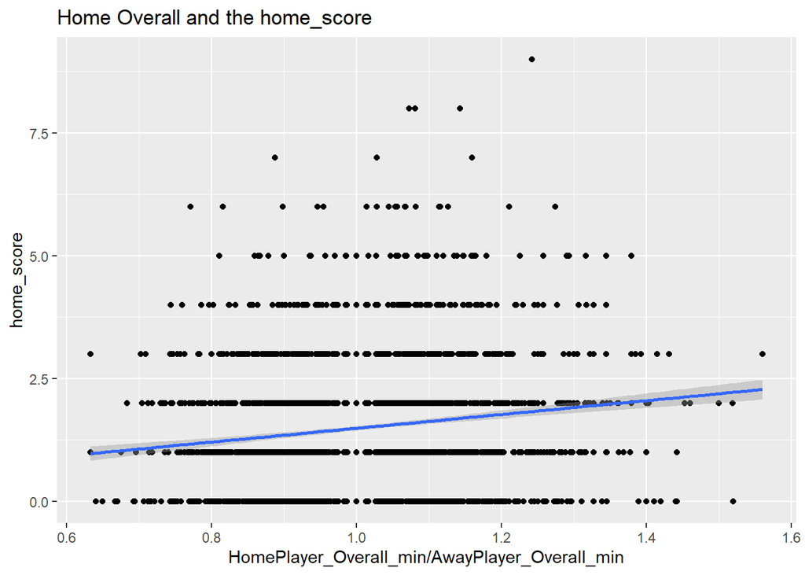

```r
ggplot(data = data, aes(x = HomePlayer_Overall_min/AwayPlayer_Overall_min,
                       y = home_score)) +
  geom_point() + stat_smooth(method = "lm") +
  ggtitle("Home Overall and the home_score")
```

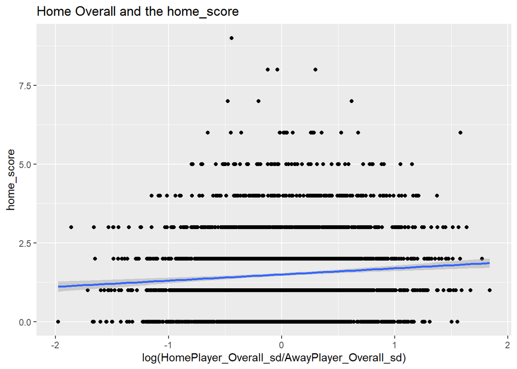

```r
ggplot(data = data, aes(x = log(HomePlayer_Overall_sd/AwayPlayer_Overall_sd),
                       y = home_score)) +
  geom_point() + stat_smooth(method = "lm") +
  ggtitle("Home Overall and the home_score")
```

And what if we do log transformation on the Overall variables

```r
lm_model <- lm(data=data, formula = GD ~
                 log(HomePlayer_Overall_mean )+
                 HomePlayer_Overall_sd+
                 log(HomePlayer_Overall_min)+
                  log(HomePlayer_Overall_max)+
               log(AwayPlayer_Overall_min)+
                  log(AwayPlayer_Overall_max)+

                 log(AwayPlayer_Overall_mean) +
                 AwayPlayer_Overall_sd  +

                 HomePlayer_Height_mean + I(HomePlayer_Height_mean^2)  +
                 AwayPlayer_Height_mean + I(AwayPlayer_Height_mean^2)  +
                 HomePlayer_Weight_mean + I(HomePlayer_Weight_mean^2)  +
                 AwayPlayer_Weight_mean + I(AwayPlayer_Weight_mean^2)  +

                 HomePlayer_Age_mean + I(HomePlayer_Age_mean^2)+
                 AwayPlayer_Age_mean + I(AwayPlayer_Age_mean^2)
               + home_team_name+ away_team_name)

  summary(lm_model)
```

```
##
## Call:
## lm(formula = GD ~ log(HomePlayer_Overall_mean) + HomePlayer_Overall_sd +
##     log(HomePlayer_Overall_min) + log(HomePlayer_Overall_max) +
##     log(AwayPlayer_Overall_min) + log(AwayPlayer_Overall_max) +
##     log(AwayPlayer_Overall_mean) + AwayPlayer_Overall_sd + HomePlayer_Height_mean +
##     I(HomePlayer_Height_mean^2) + AwayPlayer_Height_mean + I(AwayPlayer_Height_mean^2) +
##     HomePlayer_Weight_mean + I(HomePlayer_Weight_mean^2) + AwayPlayer_Weight_mean +
##     I(AwayPlayer_Weight_mean^2) + HomePlayer_Age_mean + I(HomePlayer_Age_mean^2) +
##     AwayPlayer_Age_mean + I(AwayPlayer_Age_mean^2) + home_team_name +
##     away_team_name, data = data)
##
## Residuals:
##     Min      1Q  Median      3Q     Max
## -8.8632 -1.0363 -0.0129  1.0476  7.6667
##
## Coefficients:
##                                         Estimate Std. Error t value Pr(>|t|)
## (Intercept)                           195.459263 317.860678   0.615  0.53865
## log(HomePlayer_Overall_mean)            5.068917   2.299909   2.204  0.02760
## HomePlayer_Overall_sd                  -0.032909   0.064273  -0.512  0.60868
## log(HomePlayer_Overall_min)            -1.081136   1.210424  -0.893  0.37183
## log(HomePlayer_Overall_max)             0.446995   2.531457   0.177  0.85985
## log(AwayPlayer_Overall_min)             1.671822   1.208582   1.383  0.16668
## log(AwayPlayer_Overall_max)            -2.052349   2.523740  -0.813  0.41616
## log(AwayPlayer_Overall_mean)           -4.735865   2.305021  -2.055  0.04001
## AwayPlayer_Overall_sd                   0.095258   0.064660   1.473  0.14080
## HomePlayer_Height_mean                  0.376706   2.506909   0.150  0.88056
## I(HomePlayer_Height_mean^2)            -0.000979   0.006865  -0.143  0.88661
## AwayPlayer_Height_mean                 -2.188239   2.501101  -0.875  0.38169
## I(AwayPlayer_Height_mean^2)             0.005984   0.006848   0.874  0.38226
## HomePlayer_Weight_mean                 -0.261133   0.650392  -0.402  0.68808
## I(HomePlayer_Weight_mean^2)             0.001787   0.004217   0.424  0.67178
## AwayPlayer_Weight_mean                 -0.369768   0.629190  -0.588  0.55679
## I(AwayPlayer_Weight_mean^2)             0.002360   0.004073   0.579  0.56233
## HomePlayer_Age_mean                     0.281533   0.673386   0.418  0.67592
## I(HomePlayer_Age_mean^2)               -0.006256   0.012787  -0.489  0.62469
## AwayPlayer_Age_mean                    -0.655061   0.666762  -0.982  0.32596
## I(AwayPlayer_Age_mean^2)                0.014410   0.012658   1.138  0.25506
## home_team_nameArsenal                   0.681200   0.267718   2.544  0.01099
```

[output cut: 136 more lines]

```
## away_team_nameSouthampton
## away_team_nameStoke City
## away_team_nameSunderland
## away_team_nameSwansea City
## away_team_nameTottenham Hotspur       *
## away_team_nameWatford
## away_team_nameWest Bromwich Albion    .
## away_team_nameWest Ham United         *
## away_team_nameWolverhampton Wanderers .
## ---
## Signif. codes:  0 '***' 0.001 '**' 0.01 '*' 0.05 '.' 0.1 ' ' 1
##
## Residual standard error: 1.641 on 2957 degrees of freedom
## Multiple R-squared:  0.2319, Adjusted R-squared:  0.2106
## F-statistic: 10.89 on 82 and 2957 DF,  p-value: < 2.2e-16
```

and what if we include the bench?

now without a premise on the causal effects, do we really need the min max values?

```r
lm_model <- lm(data=data, formula = GD ~
                 HomePlayer_Overall_mean +
                 HomePlayer_Overall_sd +
                 AwayPlayer_Overall_mean +
                 AwayPlayer_Overall_sd  +
                 HomePlayer_Height_mean + I(HomePlayer_Height_mean^2)  +
                 AwayPlayer_Height_mean + I(AwayPlayer_Height_mean^2)  +
                 HomePlayer_Weight_mean + I(HomePlayer_Weight_mean^2)  +
                 AwayPlayer_Weight_mean + I(AwayPlayer_Weight_mean^2)  +
                 HomePlayer_Age_mean + I(HomePlayer_Age_mean^2)+
                 AwayPlayer_Age_mean + I(AwayPlayer_Age_mean^2)
               + home_team_name+ away_team_name)
  summary(lm_model)
```

```
##
## Call:
## lm(formula = GD ~ HomePlayer_Overall_mean + HomePlayer_Overall_sd +
##     AwayPlayer_Overall_mean + AwayPlayer_Overall_sd + HomePlayer_Height_mean +
##     I(HomePlayer_Height_mean^2) + AwayPlayer_Height_mean + I(AwayPlayer_Height_mean^2) +
##     HomePlayer_Weight_mean + I(HomePlayer_Weight_mean^2) + AwayPlayer_Weight_mean +
##     I(AwayPlayer_Weight_mean^2) + HomePlayer_Age_mean + I(HomePlayer_Age_mean^2) +
##     AwayPlayer_Age_mean + I(AwayPlayer_Age_mean^2) + home_team_name +
##     away_team_name, data = data)
##
## Residuals:
##     Min      1Q  Median      3Q     Max
## -8.8285 -1.0447 -0.0214  1.0654  7.6681
##
## Coefficients:
##                                         Estimate Std. Error t value Pr(>|t|)
## (Intercept)                            2.061e+02  3.166e+02   0.651 0.515049
## HomePlayer_Overall_mean                6.252e-02  1.838e-02   3.401 0.000679
## HomePlayer_Overall_sd                  1.661e-02  1.986e-02   0.836 0.403043
## AwayPlayer_Overall_mean               -6.942e-02  1.849e-02  -3.754 0.000177
## AwayPlayer_Overall_sd                  9.003e-03  2.018e-02   0.446 0.655519
## HomePlayer_Height_mean                 3.526e-01  2.497e+00   0.141 0.887722
## I(HomePlayer_Height_mean^2)           -9.098e-04  6.838e-03  -0.133 0.894171
## AwayPlayer_Height_mean                -2.296e+00  2.494e+00  -0.921 0.357338
## I(AwayPlayer_Height_mean^2)            6.273e-03  6.829e-03   0.919 0.358425
## HomePlayer_Weight_mean                -2.353e-01  6.487e-01  -0.363 0.716796
## I(HomePlayer_Weight_mean^2)            1.619e-03  4.205e-03   0.385 0.700312
## AwayPlayer_Weight_mean                -4.107e-01  6.280e-01  -0.654 0.513116
## I(AwayPlayer_Weight_mean^2)            2.636e-03  4.065e-03   0.649 0.516702
## HomePlayer_Age_mean                    2.710e-01  6.706e-01   0.404 0.686184
## I(HomePlayer_Age_mean^2)              -6.050e-03  1.274e-02  -0.475 0.634822
## AwayPlayer_Age_mean                   -6.723e-01  6.653e-01  -1.010 0.312383
## I(AwayPlayer_Age_mean^2)               1.471e-02  1.263e-02   1.165 0.244137
## home_team_nameArsenal                  6.232e-01  2.660e-01   2.343 0.019211
## home_team_nameAston Villa             -3.412e-01  2.464e-01  -1.385 0.166271
## home_team_nameBrentford                2.109e-01  4.288e-01   0.492 0.622923
## home_team_nameBrighton & Hove Albion  -2.669e-01  2.697e-01  -0.990 0.322458
## home_team_nameBurnley                 -2.364e-01  2.448e-01  -0.965 0.334380
## home_team_nameCardiff City            -6.835e-01  4.251e-01  -1.608 0.107994
## home_team_nameChelsea                  4.467e-01  2.882e-01   1.550 0.121229
```

[output cut: 126 more lines]

```
## away_team_nameSouthampton
## away_team_nameStoke City
## away_team_nameSunderland
## away_team_nameSwansea City
## away_team_nameTottenham Hotspur       *
## away_team_nameWatford
## away_team_nameWest Bromwich Albion    .
## away_team_nameWest Ham United         *
## away_team_nameWolverhampton Wanderers .
## ---
## Signif. codes:  0 '***' 0.001 '**' 0.01 '*' 0.05 '.' 0.1 ' ' 1
##
## Residual standard error: 1.64 on 2961 degrees of freedom
## Multiple R-squared:  0.2318, Adjusted R-squared:  0.2115
## F-statistic: 11.45 on 78 and 2961 DF,  p-value: < 2.2e-16
```

```r
  ### and bmi

data$HomePlayer_MHeight_mean = data$HomePlayer_Height_mean / 100
data$AwayPlayer_MHeight_mean = data$AwayPlayer_Height_mean / 100

data$Home_BMI = data$HomePlayer_Weight_mean / data$HomePlayer_MHeight_mean^2
data$Away_BMI = data$AwayPlayer_Weight_mean / data$AwayPlayer_MHeight_mean^2
lm_model <- lm(data=data, formula = GD ~
                 HomePlayer_Overall_max+
               HomePlayer_Overall_min +
              AwayPlayer_Overall_min+
               AwayPlayer_Overall_max+
                 HomePlayer_Overall_mean + HomePlayer_bench_Overall_mean +
                 HomePlayer_Overall_sd +
                 AwayPlayer_Overall_mean +
                 AwayPlayer_Overall_sd  +
                 HomePlayer_Height_mean + I(HomePlayer_Height_mean^2)  +
                 AwayPlayer_Height_mean + I(AwayPlayer_Height_mean^2)  +
                 HomePlayer_Weight_mean + I(HomePlayer_Weight_mean^2)  +
                 AwayPlayer_Weight_mean + I(AwayPlayer_Weight_mean^2)  +
                 HomePlayer_Age_mean + I(HomePlayer_Age_mean^2)+
                 AwayPlayer_Age_mean + I(AwayPlayer_Age_mean^2)
               + home_team_name+ away_team_name)
  summary(lm_model)
```

```
##
## Call:
## lm(formula = GD ~ HomePlayer_Overall_max + HomePlayer_Overall_min +
##     AwayPlayer_Overall_min + AwayPlayer_Overall_max + HomePlayer_Overall_mean +
##     HomePlayer_bench_Overall_mean + HomePlayer_Overall_sd + AwayPlayer_Overall_mean +
##     AwayPlayer_Overall_sd + HomePlayer_Height_mean + I(HomePlayer_Height_mean^2) +
##     AwayPlayer_Height_mean + I(AwayPlayer_Height_mean^2) + HomePlayer_Weight_mean +
##     I(HomePlayer_Weight_mean^2) + AwayPlayer_Weight_mean + I(AwayPlayer_Weight_mean^2) +
##     HomePlayer_Age_mean + I(HomePlayer_Age_mean^2) + AwayPlayer_Age_mean +
##     I(AwayPlayer_Age_mean^2) + home_team_name + away_team_name,
##     data = data)
##
## Residuals:
##    Min     1Q Median     3Q    Max
## -8.885 -1.035 -0.018  1.045  7.619
##
## Coefficients:
##                                         Estimate Std. Error t value Pr(>|t|)
## (Intercept)                            1.836e+02  3.176e+02   0.578  0.56321
## HomePlayer_Overall_max                -3.145e-04  3.090e-02  -0.010  0.99188
## HomePlayer_Overall_min                -1.388e-02  1.827e-02  -0.760  0.44734
## AwayPlayer_Overall_min                 1.928e-02  1.818e-02   1.061  0.28899
## AwayPlayer_Overall_max                -2.211e-02  3.082e-02  -0.717  0.47321
## HomePlayer_Overall_mean                6.841e-02  3.018e-02   2.267  0.02348
## HomePlayer_bench_Overall_mean          1.677e-02  1.296e-02   1.294  0.19572
## HomePlayer_Overall_sd                 -2.371e-02  6.340e-02  -0.374  0.70845
## AwayPlayer_Overall_mean               -6.694e-02  3.007e-02  -2.226  0.02608
## AwayPlayer_Overall_sd                  7.478e-02  6.370e-02   1.174  0.24053
## HomePlayer_Height_mean                 5.240e-01  2.506e+00   0.209  0.83443
## I(HomePlayer_Height_mean^2)           -1.375e-03  6.863e-03  -0.200  0.84128
## AwayPlayer_Height_mean                -2.226e+00  2.501e+00  -0.890  0.37351
## I(AwayPlayer_Height_mean^2)            6.086e-03  6.848e-03   0.889  0.37415
## HomePlayer_Weight_mean                -2.404e-01  6.498e-01  -0.370  0.71141
## I(HomePlayer_Weight_mean^2)            1.638e-03  4.214e-03   0.389  0.69749
## AwayPlayer_Weight_mean                -4.274e-01  6.296e-01  -0.679  0.49732
## I(AwayPlayer_Weight_mean^2)            2.731e-03  4.075e-03   0.670  0.50277
## HomePlayer_Age_mean                    2.617e-01  6.745e-01   0.388  0.69812
## I(HomePlayer_Age_mean^2)              -5.870e-03  1.281e-02  -0.458  0.64673
## AwayPlayer_Age_mean                   -6.261e-01  6.673e-01  -0.938  0.34818
## I(AwayPlayer_Age_mean^2)               1.394e-02  1.267e-02   1.101  0.27103
```

[output cut: 138 more lines]

```
## away_team_nameSouthampton
## away_team_nameStoke City
## away_team_nameSunderland
## away_team_nameSwansea City
## away_team_nameTottenham Hotspur       *
## away_team_nameWatford
## away_team_nameWest Bromwich Albion    .
## away_team_nameWest Ham United         *
## away_team_nameWolverhampton Wanderers .
## ---
## Signif. codes:  0 '***' 0.001 '**' 0.01 '*' 0.05 '.' 0.1 ' ' 1
##
## Residual standard error: 1.64 on 2956 degrees of freedom
## Multiple R-squared:  0.2327, Adjusted R-squared:  0.2112
## F-statistic:  10.8 on 83 and 2956 DF,  p-value: < 2.2e-16
```

While looking at the adjusted R^2, the best models are the ones that take into account only the mean and sd, is enough.

We will try 2 different approaches in our ML probability extraction

1. Assume GD is normal, use the regression output as a mean, and by that extract probabilities
2. Assume home_score and away_score are poisson variables and as such use the regression outputs of both home_score and away_score, and extract them using a skellam distribution

```r
data$GD = data$home_score - data$away_score
new_lm <- lm(data=data, formula = home_score ~ log(HomePlayer_Dribbling_mean) +
               log(HomePlayer_Shooting_mean) + log(HomePlayer_Passing_mean) + log(HomePlayer_Physicality_mean)+
               log(HomePlayer_Defending_mean) + log(HomePlayer_Pace_mean) + log(AwayPlayer_Dribbling_mean) +
               log(AwayPlayer_Shooting_mean) + log(AwayPlayer_Passing_mean) + log(AwayPlayer_Physicality_mean)+
               log(AwayPlayer_Defending_mean) + log(AwayPlayer_Pace_mean) + HomePlayer_Age_mean + AwayPlayer_Age_mean + I(HomePlayer_Age_mean^2) +I(AwayPlayer_Age_mean^2) + home_team_name + away_team_name)
summary(new_lm)
```

```
##
## Call:
## lm(formula = home_score ~ log(HomePlayer_Dribbling_mean) + log(HomePlayer_Shooting_mean) +
##     log(HomePlayer_Passing_mean) + log(HomePlayer_Physicality_mean) +
##     log(HomePlayer_Defending_mean) + log(HomePlayer_Pace_mean) +
##     log(AwayPlayer_Dribbling_mean) + log(AwayPlayer_Shooting_mean) +
##     log(AwayPlayer_Passing_mean) + log(AwayPlayer_Physicality_mean) +
##     log(AwayPlayer_Defending_mean) + log(AwayPlayer_Pace_mean) +
##     HomePlayer_Age_mean + AwayPlayer_Age_mean + I(HomePlayer_Age_mean^2) +
##     I(AwayPlayer_Age_mean^2) + home_team_name + away_team_name,
##     data = data)
##
## Residuals:
##     Min      1Q  Median      3Q     Max
## -2.7548 -0.8780 -0.1315  0.6938  6.8722
##
## Coefficients:
##                                        Estimate Std. Error t value Pr(>|t|)
## (Intercept)                            1.163332   9.288018   0.125 0.900334
## log(HomePlayer_Dribbling_mean)         0.428328   1.415308   0.303 0.762186
## log(HomePlayer_Shooting_mean)          1.177284   0.732097   1.608 0.107920
## log(HomePlayer_Passing_mean)           0.098025   1.296266   0.076 0.939726
## log(HomePlayer_Physicality_mean)       0.883825   0.991787   0.891 0.372925
## log(HomePlayer_Defending_mean)         1.106877   0.600350   1.844 0.065324 .
## log(HomePlayer_Pace_mean)             -0.233375   0.703596  -0.332 0.740148
## log(AwayPlayer_Dribbling_mean)         1.935344   1.396100   1.386 0.165775
## log(AwayPlayer_Shooting_mean)         -0.182496   0.712393  -0.256 0.797835
## log(AwayPlayer_Passing_mean)          -1.965603   1.313426  -1.497 0.134618
## log(AwayPlayer_Physicality_mean)       0.355310   0.984212   0.361 0.718118
## log(AwayPlayer_Defending_mean)        -0.996622   0.607716  -1.640 0.101123
## log(AwayPlayer_Pace_mean)             -0.520544   0.690245  -0.754 0.450823
## HomePlayer_Age_mean                    0.074138   0.487992   0.152 0.879256
## AwayPlayer_Age_mean                   -0.671315   0.484111  -1.387 0.165639
## I(HomePlayer_Age_mean^2)              -0.002384   0.009321  -0.256 0.798121
## I(AwayPlayer_Age_mean^2)               0.013546   0.009240   1.466 0.142735
## home_team_nameArsenal                  0.239523   0.176754   1.355 0.175484
## home_team_nameAston Villa             -0.409933   0.180947  -2.265 0.023554 *
## home_team_nameBrentford               -0.364193   0.315897  -1.153 0.249050
## home_team_nameBrighton & Hove Albion  -0.507783   0.209575  -2.423 0.015456 *
## home_team_nameBurnley                 -0.550481   0.184020  -2.991 0.002800 **
```

[output cut: 48 more lines]

```
## away_team_nameSouthampton             -0.438820   0.175504  -2.500 0.012461 *
## away_team_nameStoke City              -0.533792   0.207426  -2.573 0.010119 *
## away_team_nameSunderland              -0.350371   0.202289  -1.732 0.083373 .
## away_team_nameSwansea City            -0.415977   0.199540  -2.085 0.037184 *
## away_team_nameTottenham Hotspur       -0.477380   0.192566  -2.479 0.013229 *
## away_team_nameWatford                 -0.333400   0.194301  -1.716 0.086286 .
## away_team_nameWest Bromwich Albion    -0.546013   0.200164  -2.728 0.006413 **
## away_team_nameWest Ham United         -0.476157   0.173692  -2.741 0.006155 **
## away_team_nameWolverhampton Wanderers -0.698978   0.206917  -3.378 0.000739 ***
## ---
## Signif. codes:  0 '***' 0.001 '**' 0.01 '*' 0.05 '.' 0.1 ' ' 1
##
## Residual standard error: 1.194 on 2961 degrees of freedom
## Multiple R-squared:  0.1625, Adjusted R-squared:  0.1404
## F-statistic: 7.364 on 78 and 2961 DF,  p-value: < 2.2e-16
```

```r
data$GD = data$home_score - data$away_score
new_lm <- lm(data=data, formula = home_score ~  (HomePlayer_Dribbling_mean) +
                (HomePlayer_Shooting_mean) +  (HomePlayer_Passing_mean) +  (HomePlayer_Physicality_mean)+
                (HomePlayer_Defending_mean) +  (HomePlayer_Pace_mean) +  (AwayPlayer_Dribbling_mean) +
                (AwayPlayer_Shooting_mean) +  (AwayPlayer_Passing_mean) +  (AwayPlayer_Physicality_mean)+
                (AwayPlayer_Defending_mean) +  (AwayPlayer_Pace_mean) + HomePlayer_Age_mean + AwayPlayer_Age_mean + I(HomePlayer_Age_mean^2) +I(AwayPlayer_Age_mean^2) + home_team_name + away_team_name)
summary(new_lm)
```

```
##
## Call:
## lm(formula = home_score ~ (HomePlayer_Dribbling_mean) + (HomePlayer_Shooting_mean) +
##     (HomePlayer_Passing_mean) + (HomePlayer_Physicality_mean) +
##     (HomePlayer_Defending_mean) + (HomePlayer_Pace_mean) + (AwayPlayer_Dribbling_mean) +
##     (AwayPlayer_Shooting_mean) + (AwayPlayer_Passing_mean) +
##     (AwayPlayer_Physicality_mean) + (AwayPlayer_Defending_mean) +
##     (AwayPlayer_Pace_mean) + HomePlayer_Age_mean + AwayPlayer_Age_mean +
##     I(HomePlayer_Age_mean^2) + I(AwayPlayer_Age_mean^2) + home_team_name +
##     away_team_name, data = data)
##
## Residuals:
##     Min      1Q  Median      3Q     Max
## -2.7648 -0.8804 -0.1318  0.6976  6.8619
##
## Coefficients:
##                                         Estimate Std. Error t value Pr(>|t|)
## (Intercept)                            7.7417251  8.7091382   0.889 0.374118
## HomePlayer_Dribbling_mean              0.0071973  0.0202939   0.355 0.722874
## HomePlayer_Shooting_mean               0.0194568  0.0122084   1.594 0.111104
## HomePlayer_Passing_mean                0.0004958  0.0194139   0.026 0.979626
## HomePlayer_Physicality_mean            0.0125231  0.0138236   0.906 0.365053
## HomePlayer_Defending_mean              0.0198023  0.0099219   1.996 0.046045
## HomePlayer_Pace_mean                  -0.0031024  0.0102896  -0.302 0.763047
## AwayPlayer_Dribbling_mean              0.0264796  0.0200643   1.320 0.187023
## AwayPlayer_Shooting_mean              -0.0041835  0.0119394  -0.350 0.726070
## AwayPlayer_Passing_mean               -0.0276731  0.0197259  -1.403 0.160758
## AwayPlayer_Physicality_mean            0.0070329  0.0137091   0.513 0.607982
## AwayPlayer_Defending_mean             -0.0185835  0.0099623  -1.865 0.062227
## AwayPlayer_Pace_mean                  -0.0085495  0.0101242  -0.844 0.398481
## HomePlayer_Age_mean                    0.0671634  0.4871660   0.138 0.890356
## AwayPlayer_Age_mean                   -0.6542937  0.4833255  -1.354 0.175925
## I(HomePlayer_Age_mean^2)              -0.0022824  0.0093039  -0.245 0.806225
## I(AwayPlayer_Age_mean^2)               0.0132341  0.0092231   1.435 0.151425
## home_team_nameArsenal                  0.2360978  0.1769042   1.335 0.182107
## home_team_nameAston Villa             -0.4163401  0.1809171  -2.301 0.021445
## home_team_nameBrentford               -0.3689190  0.3156129  -1.169 0.242539
## home_team_nameBrighton & Hove Albion  -0.5046440  0.2094286  -2.410 0.016030
## home_team_nameBurnley                 -0.5532969  0.1841635  -3.004 0.002684
## home_team_nameCardiff City            -0.2737962  0.3170675  -0.864 0.387918
```

[output cut: 127 more lines]

```
## away_team_nameSouthampton             *
## away_team_nameStoke City              **
## away_team_nameSunderland              .
## away_team_nameSwansea City            *
## away_team_nameTottenham Hotspur       *
## away_team_nameWatford                 .
## away_team_nameWest Bromwich Albion    **
## away_team_nameWest Ham United         **
## away_team_nameWolverhampton Wanderers ***
## ---
## Signif. codes:  0 '***' 0.001 '**' 0.01 '*' 0.05 '.' 0.1 ' ' 1
##
## Residual standard error: 1.194 on 2961 degrees of freedom
## Multiple R-squared:  0.1631, Adjusted R-squared:  0.1411
## F-statistic: 7.399 on 78 and 2961 DF,  p-value: < 2.2e-16
```

```r
pois_reg <- glm(data=data, formula = home_score ~  log(HomePlayer_Dribbling_mean) +
                (HomePlayer_Shooting_mean) +  log(HomePlayer_Passing_mean) +  (HomePlayer_Physicality_mean)+
                (HomePlayer_Defending_mean) +  (HomePlayer_Pace_mean) +  (AwayPlayer_Dribbling_mean) +
                (AwayPlayer_Shooting_mean) +  (AwayPlayer_Passing_mean) +  (AwayPlayer_Physicality_mean)+
                (AwayPlayer_Defending_mean) +  (AwayPlayer_Pace_mean) + HomePlayer_Age_mean + AwayPlayer_Age_mean + I(HomePlayer_Age_mean^2) +I(AwayPlayer_Age_mean^2) + home_team_name + away_team_name, family='poisson')

summary(pois_reg)
```

```
##
## Call:
## glm(formula = home_score ~ log(HomePlayer_Dribbling_mean) + (HomePlayer_Shooting_mean) +
##     log(HomePlayer_Passing_mean) + (HomePlayer_Physicality_mean) +
##     (HomePlayer_Defending_mean) + (HomePlayer_Pace_mean) + (AwayPlayer_Dribbling_mean) +
##     (AwayPlayer_Shooting_mean) + (AwayPlayer_Passing_mean) +
##     (AwayPlayer_Physicality_mean) + (AwayPlayer_Defending_mean) +
##     (AwayPlayer_Pace_mean) + HomePlayer_Age_mean + AwayPlayer_Age_mean +
##     I(HomePlayer_Age_mean^2) + I(AwayPlayer_Age_mean^2) + home_team_name +
##     away_team_name, family = "poisson", data = data)
##
## Deviance Residuals:
##     Min       1Q   Median       3Q      Max
## -2.4078  -0.9963  -0.1129   0.5515   3.9221
##
## Coefficients:
##                                         Estimate Std. Error z value Pr(>|z|)
## (Intercept)                            4.111e+00  6.428e+00   0.640  0.52247
## log(HomePlayer_Dribbling_mean)         2.301e-01  9.982e-01   0.231  0.81768
## HomePlayer_Shooting_mean               1.381e-02  8.386e-03   1.646  0.09968
## log(HomePlayer_Passing_mean)           7.768e-02  9.097e-01   0.085  0.93195
## HomePlayer_Physicality_mean            8.087e-03  9.554e-03   0.846  0.39728
## HomePlayer_Defending_mean              1.300e-02  6.762e-03   1.922  0.05457
## HomePlayer_Pace_mean                  -1.666e-03  7.126e-03  -0.234  0.81509
## AwayPlayer_Dribbling_mean              1.656e-02  1.363e-02   1.215  0.22443
## AwayPlayer_Shooting_mean              -3.587e-03  8.264e-03  -0.434  0.66428
## AwayPlayer_Passing_mean               -1.688e-02  1.353e-02  -1.248  0.21217
## AwayPlayer_Physicality_mean            4.679e-03  9.342e-03   0.501  0.61647
## AwayPlayer_Defending_mean             -1.261e-02  6.844e-03  -1.842  0.06546
## AwayPlayer_Pace_mean                  -4.569e-03  6.848e-03  -0.667  0.50463
## HomePlayer_Age_mean                    7.429e-05  3.373e-01   0.000  0.99982
## AwayPlayer_Age_mean                   -4.421e-01  3.248e-01  -1.361  0.17347
## I(HomePlayer_Age_mean^2)              -6.501e-04  6.454e-03  -0.101  0.91977
## I(AwayPlayer_Age_mean^2)               8.955e-03  6.193e-03   1.446  0.14821
## home_team_nameArsenal                  1.285e-01  1.179e-01   1.090  0.27553
## home_team_nameAston Villa             -3.103e-01  1.319e-01  -2.353  0.01860
## home_team_nameBrentford               -2.698e-01  2.391e-01  -1.128  0.25914
## home_team_nameBrighton & Hove Albion  -3.900e-01  1.565e-01  -2.492  0.01271
## home_team_nameBurnley                 -4.394e-01  1.369e-01  -3.209  0.00133
## home_team_nameCardiff City            -2.194e-01  2.454e-01  -0.894  0.37130
```

[output cut: 131 more lines]

```
## away_team_nameTottenham Hotspur       *
## away_team_nameWatford
## away_team_nameWest Bromwich Albion    *
## away_team_nameWest Ham United         *
## away_team_nameWolverhampton Wanderers **
## ---
## Signif. codes:  0 '***' 0.001 '**' 0.01 '*' 0.05 '.' 0.1 ' ' 1
##
## (Dispersion parameter for poisson family taken to be 1)
##
##     Null deviance: 3811.2  on 3039  degrees of freedom
## Residual deviance: 3274.3  on 2961  degrees of freedom
## AIC: 9164.8
##
## Number of Fisher Scoring iterations: 5
```

```r
simple_lm <- lm(data=data, formula = home_score ~  log(HomePlayer_Dribbling_mean) +
                (HomePlayer_Shooting_mean) +  log(HomePlayer_Passing_mean) +  (HomePlayer_Physicality_mean)+
                (HomePlayer_Defending_mean) +  (HomePlayer_Pace_mean) +  (AwayPlayer_Dribbling_mean) +
                (AwayPlayer_Shooting_mean) +  (AwayPlayer_Passing_mean) +  (AwayPlayer_Physicality_mean)+
                (AwayPlayer_Defending_mean) +  (AwayPlayer_Pace_mean) + HomePlayer_Age_mean + AwayPlayer_Age_mean + I(HomePlayer_Age_mean^2) +I(AwayPlayer_Age_mean^2) + home_team_name + away_team_name)
summary(simple_lm)
```

```
##
## Call:
## lm(formula = home_score ~ log(HomePlayer_Dribbling_mean) + (HomePlayer_Shooting_mean) +
##     log(HomePlayer_Passing_mean) + (HomePlayer_Physicality_mean) +
##     (HomePlayer_Defending_mean) + (HomePlayer_Pace_mean) + (AwayPlayer_Dribbling_mean) +
##     (AwayPlayer_Shooting_mean) + (AwayPlayer_Passing_mean) +
##     (AwayPlayer_Physicality_mean) + (AwayPlayer_Defending_mean) +
##     (AwayPlayer_Pace_mean) + HomePlayer_Age_mean + AwayPlayer_Age_mean +
##     I(HomePlayer_Age_mean^2) + I(AwayPlayer_Age_mean^2) + home_team_name +
##     away_team_name, data = data)
##
## Residuals:
##     Min      1Q  Median      3Q     Max
## -2.7599 -0.8825 -0.1321  0.6973  6.8648
##
## Coefficients:
##                                        Estimate Std. Error t value Pr(>|t|)
## (Intercept)                            6.303022   9.390081   0.671 0.502118
## log(HomePlayer_Dribbling_mean)         0.459817   1.417608   0.324 0.745688
## HomePlayer_Shooting_mean               0.020353   0.012201   1.668 0.095402 .
## log(HomePlayer_Passing_mean)          -0.024136   1.298488  -0.019 0.985171
## HomePlayer_Physicality_mean            0.011815   0.013805   0.856 0.392163
## HomePlayer_Defending_mean              0.020403   0.009934   2.054 0.040090 *
## HomePlayer_Pace_mean                  -0.002749   0.010278  -0.267 0.789162
## AwayPlayer_Dribbling_mean              0.026672   0.020054   1.330 0.183631
## AwayPlayer_Shooting_mean              -0.004160   0.011939  -0.348 0.727556
## AwayPlayer_Passing_mean               -0.027800   0.019721  -1.410 0.158747
## AwayPlayer_Physicality_mean            0.006942   0.013707   0.506 0.612576
## AwayPlayer_Defending_mean             -0.018483   0.009958  -1.856 0.063537 .
## AwayPlayer_Pace_mean                  -0.008626   0.010120  -0.852 0.394074
## HomePlayer_Age_mean                    0.072837   0.486770   0.150 0.881064
## AwayPlayer_Age_mean                   -0.655783   0.483317  -1.357 0.174936
## I(HomePlayer_Age_mean^2)              -0.002383   0.009297  -0.256 0.797757
## I(AwayPlayer_Age_mean^2)               0.013260   0.009223   1.438 0.150627
## home_team_nameArsenal                  0.239892   0.176609   1.358 0.174466
## home_team_nameAston Villa             -0.416023   0.180943  -2.299 0.021563 *
## home_team_nameBrentford               -0.369510   0.315773  -1.170 0.242024
## home_team_nameBrighton & Hove Albion  -0.503648   0.209434  -2.405 0.016242 *
## home_team_nameBurnley                 -0.552512   0.184158  -3.000 0.002721 **
## home_team_nameCardiff City            -0.275718   0.317445  -0.869 0.385162
```

[output cut: 47 more lines]

```
## away_team_nameSouthampton             -0.442561   0.175621  -2.520 0.011789 *
## away_team_nameStoke City              -0.539833   0.207186  -2.606 0.009219 **
## away_team_nameSunderland              -0.351883   0.202309  -1.739 0.082081 .
## away_team_nameSwansea City            -0.416378   0.199335  -2.089 0.036808 *
## away_team_nameTottenham Hotspur       -0.460919   0.193622  -2.381 0.017352 *
## away_team_nameWatford                 -0.339405   0.194388  -1.746 0.080911 .
## away_team_nameWest Bromwich Albion    -0.546676   0.199772  -2.736 0.006247 **
## away_team_nameWest Ham United         -0.476700   0.173702  -2.744 0.006100 **
## away_team_nameWolverhampton Wanderers -0.705176   0.207067  -3.406 0.000669 ***
## ---
## Signif. codes:  0 '***' 0.001 '**' 0.01 '*' 0.05 '.' 0.1 ' ' 1
##
## Residual standard error: 1.194 on 2961 degrees of freedom
## Multiple R-squared:  0.1631, Adjusted R-squared:  0.141
## F-statistic: 7.398 on 78 and 2961 DF,  p-value: < 2.2e-16
```

```r
summary(pois_reg)
```

```
##
## Call:
## glm(formula = home_score ~ log(HomePlayer_Dribbling_mean) + (HomePlayer_Shooting_mean) +
##     log(HomePlayer_Passing_mean) + (HomePlayer_Physicality_mean) +
##     (HomePlayer_Defending_mean) + (HomePlayer_Pace_mean) + (AwayPlayer_Dribbling_mean) +
##     (AwayPlayer_Shooting_mean) + (AwayPlayer_Passing_mean) +
##     (AwayPlayer_Physicality_mean) + (AwayPlayer_Defending_mean) +
##     (AwayPlayer_Pace_mean) + HomePlayer_Age_mean + AwayPlayer_Age_mean +
##     I(HomePlayer_Age_mean^2) + I(AwayPlayer_Age_mean^2) + home_team_name +
##     away_team_name, family = "poisson", data = data)
##
## Deviance Residuals:
##     Min       1Q   Median       3Q      Max
## -2.4078  -0.9963  -0.1129   0.5515   3.9221
##
## Coefficients:
##                                         Estimate Std. Error z value Pr(>|z|)
## (Intercept)                            4.111e+00  6.428e+00   0.640  0.52247
## log(HomePlayer_Dribbling_mean)         2.301e-01  9.982e-01   0.231  0.81768
## HomePlayer_Shooting_mean               1.381e-02  8.386e-03   1.646  0.09968
## log(HomePlayer_Passing_mean)           7.768e-02  9.097e-01   0.085  0.93195
## HomePlayer_Physicality_mean            8.087e-03  9.554e-03   0.846  0.39728
## HomePlayer_Defending_mean              1.300e-02  6.762e-03   1.922  0.05457
## HomePlayer_Pace_mean                  -1.666e-03  7.126e-03  -0.234  0.81509
## AwayPlayer_Dribbling_mean              1.656e-02  1.363e-02   1.215  0.22443
## AwayPlayer_Shooting_mean              -3.587e-03  8.264e-03  -0.434  0.66428
## AwayPlayer_Passing_mean               -1.688e-02  1.353e-02  -1.248  0.21217
## AwayPlayer_Physicality_mean            4.679e-03  9.342e-03   0.501  0.61647
## AwayPlayer_Defending_mean             -1.261e-02  6.844e-03  -1.842  0.06546
## AwayPlayer_Pace_mean                  -4.569e-03  6.848e-03  -0.667  0.50463
## HomePlayer_Age_mean                    7.429e-05  3.373e-01   0.000  0.99982
## AwayPlayer_Age_mean                   -4.421e-01  3.248e-01  -1.361  0.17347
## I(HomePlayer_Age_mean^2)              -6.501e-04  6.454e-03  -0.101  0.91977
## I(AwayPlayer_Age_mean^2)               8.955e-03  6.193e-03   1.446  0.14821
## home_team_nameArsenal                  1.285e-01  1.179e-01   1.090  0.27553
## home_team_nameAston Villa             -3.103e-01  1.319e-01  -2.353  0.01860
## home_team_nameBrentford               -2.698e-01  2.391e-01  -1.128  0.25914
## home_team_nameBrighton & Hove Albion  -3.900e-01  1.565e-01  -2.492  0.01271
## home_team_nameBurnley                 -4.394e-01  1.369e-01  -3.209  0.00133
## home_team_nameCardiff City            -2.194e-01  2.454e-01  -0.894  0.37130
```

[output cut: 131 more lines]

```
## away_team_nameTottenham Hotspur       *
## away_team_nameWatford
## away_team_nameWest Bromwich Albion    *
## away_team_nameWest Ham United         *
## away_team_nameWolverhampton Wanderers **
## ---
## Signif. codes:  0 '***' 0.001 '**' 0.01 '*' 0.05 '.' 0.1 ' ' 1
##
## (Dispersion parameter for poisson family taken to be 1)
##
##     Null deviance: 3811.2  on 3039  degrees of freedom
## Residual deviance: 3274.3  on 2961  degrees of freedom
## AIC: 9164.8
##
## Number of Fisher Scoring iterations: 5
```

```r
pois_ovr <- glm(data=data, formula = home_score ~
                  HomePlayer_Overall_max+AwayPlayer_Overall_max+
                 I(HomePlayer_Overall_max /AwayPlayer_Overall_max)  +
                  HomePlayer_Overall_min+AwayPlayer_Overall_min+
                I(HomePlayer_Overall_min/AwayPlayer_Overall_min) +
                 I(HomePlayer_Overall_mean/AwayPlayer_Overall_mean) +
                  AwayPlayer_Overall_mean +HomePlayer_Overall_mean +
                 HomePlayer_Overall_sd +
                 AwayPlayer_Overall_mean +
                 AwayPlayer_Overall_sd
               + home_team_name+ away_team_name, family = 'poisson')
  summary(pois_ovr)
```

```
##
## Call:
## glm(formula = home_score ~ HomePlayer_Overall_max + AwayPlayer_Overall_max +
##     I(HomePlayer_Overall_max/AwayPlayer_Overall_max) + HomePlayer_Overall_min +
##     AwayPlayer_Overall_min + I(HomePlayer_Overall_min/AwayPlayer_Overall_min) +
##     I(HomePlayer_Overall_mean/AwayPlayer_Overall_mean) + AwayPlayer_Overall_mean +
##     HomePlayer_Overall_mean + HomePlayer_Overall_sd + AwayPlayer_Overall_mean +
##     AwayPlayer_Overall_sd + home_team_name + away_team_name,
##     family = "poisson", data = data)
##
## Deviance Residuals:
##     Min       1Q   Median       3Q      Max
## -2.3880  -1.0009  -0.1110   0.5592   4.1095
##
## Coefficients:
##                                                     Estimate Std. Error z value
## (Intercept)                                         4.340167   5.069391   0.856
## HomePlayer_Overall_max                             -0.006921   0.077138  -0.090
## AwayPlayer_Overall_max                             -0.010278   0.079381  -0.129
## I(HomePlayer_Overall_max/AwayPlayer_Overall_max)    0.833400   6.137507   0.136
## HomePlayer_Overall_min                              0.020444   0.019968   1.024
## AwayPlayer_Overall_min                             -0.014713   0.021469  -0.685
## I(HomePlayer_Overall_min/AwayPlayer_Overall_min)   -1.826746   1.233617  -1.481
## I(HomePlayer_Overall_mean/AwayPlayer_Overall_mean) -4.380799   7.551928  -0.580
## AwayPlayer_Overall_mean                            -0.057819   0.102231  -0.566
## HomePlayer_Overall_mean                             0.091920   0.100849   0.911
## HomePlayer_Overall_sd                              -0.009292   0.030371  -0.306
## AwayPlayer_Overall_sd                               0.054023   0.031862   1.696
## home_team_nameArsenal                               0.047471   0.128591   0.369
## home_team_nameAston Villa                          -0.267262   0.130514  -2.048
## home_team_nameBrentford                            -0.180359   0.236492  -0.763
## home_team_nameBrighton & Hove Albion               -0.369648   0.148125  -2.496
## home_team_nameBurnley                              -0.399729   0.129250  -3.093
## home_team_nameCardiff City                         -0.235968   0.240329  -0.982
## home_team_nameChelsea                               0.010442   0.135821   0.077
## home_team_nameCrystal Palace                       -0.345910   0.124079  -2.788
## home_team_nameEverton                              -0.092240   0.122160  -0.755
## home_team_nameFulham                               -0.592782   0.205405  -2.886
## home_team_nameHuddersfield Town                    -1.008756   0.330746  -3.050
## home_team_nameHull City                            -0.196719   0.158141  -1.244
```

[output cut: 120 more lines]

```
## away_team_nameTottenham Hotspur                    0.005750 **
## away_team_nameWatford                              0.305439
## away_team_nameWest Bromwich Albion                 0.013349 *
## away_team_nameWest Ham United                      0.009151 **
## away_team_nameWolverhampton Wanderers              0.000279 ***
## ---
## Signif. codes:  0 '***' 0.001 '**' 0.01 '*' 0.05 '.' 0.1 ' ' 1
##
## (Dispersion parameter for poisson family taken to be 1)
##
##     Null deviance: 3811.2  on 3039  degrees of freedom
## Residual deviance: 3286.5  on 2966  degrees of freedom
## AIC: 9167.1
##
## Number of Fisher Scoring iterations: 5
```

```r
  pois_ovr <- glm(data=data, formula = home_score ~
                 I(HomePlayer_Overall_mean/AwayPlayer_Overall_mean)
                +I(HomePlayer_Overall_sd/AwayPlayer_Overall_sd)
               + home_team_name+ away_team_name, family = 'poisson')
  summary(pois_ovr)
```

```
##
## Call:
## glm(formula = home_score ~ I(HomePlayer_Overall_mean/AwayPlayer_Overall_mean) +
##     I(HomePlayer_Overall_sd/AwayPlayer_Overall_sd) + home_team_name +
##     away_team_name, family = "poisson", data = data)
##
## Deviance Residuals:
##     Min       1Q   Median       3Q      Max
## -2.3359  -0.9797  -0.1140   0.5646   4.1024
##
## Coefficients:
##                                                     Estimate Std. Error z value
## (Intercept)                                        -0.599839   0.487089  -1.231
## I(HomePlayer_Overall_mean/AwayPlayer_Overall_mean)  1.274951   0.461136   2.765
## I(HomePlayer_Overall_sd/AwayPlayer_Overall_sd)     -0.004042   0.022814  -0.177
## home_team_nameArsenal                               0.142523   0.120550   1.182
## home_team_nameAston Villa                          -0.260336   0.129905  -2.004
## home_team_nameBrentford                            -0.215646   0.234408  -0.920
## home_team_nameBrighton & Hove Albion               -0.354201   0.147334  -2.404
## home_team_nameBurnley                              -0.394251   0.129033  -3.055
## home_team_nameCardiff City                         -0.270736   0.238940  -1.133
## home_team_nameChelsea                               0.134275   0.123873   1.084
## home_team_nameCrystal Palace                       -0.332805   0.123748  -2.689
## home_team_nameEverton                              -0.023346   0.119389  -0.196
## home_team_nameFulham                               -0.571795   0.203715  -2.807
## home_team_nameHuddersfield Town                    -1.009907   0.330594  -3.055
## home_team_nameHull City                            -0.211947   0.156383  -1.355
## home_team_nameLeeds United                         -0.147784   0.174576  -0.847
## home_team_nameLeicester City                        0.060002   0.116240   0.516
## home_team_nameLiverpool                             0.219323   0.121824   1.800
## home_team_nameManchester City                       0.381053   0.121838   3.128
## home_team_nameManchester United                     0.081926   0.123827   0.662
## home_team_nameMiddlesbrough                        -0.488655   0.260931  -1.873
## home_team_nameNewcastle United                     -0.090589   0.121351  -0.747
## home_team_nameNorwich City                         -0.352709   0.163701  -2.155
## home_team_nameQueens Park Rangers                  -0.166614   0.176129  -0.946
## home_team_nameSheffield United                     -0.412370   0.192323  -2.144
## home_team_nameSouthampton                          -0.012848   0.116993  -0.110
## home_team_nameStoke City                           -0.057773   0.136242  -0.424
## home_team_nameSunderland                           -0.454898   0.152658  -2.980
```

[output cut: 98 more lines]

```
## away_team_nameTottenham Hotspur                    0.006041 **
## away_team_nameWatford                              0.409042
## away_team_nameWest Bromwich Albion                 0.007113 **
## away_team_nameWest Ham United                      0.015766 *
## away_team_nameWolverhampton Wanderers              0.000527 ***
## ---
## Signif. codes:  0 '***' 0.001 '**' 0.01 '*' 0.05 '.' 0.1 ' ' 1
##
## (Dispersion parameter for poisson family taken to be 1)
##
##     Null deviance: 3811.2  on 3039  degrees of freedom
## Residual deviance: 3300.1  on 2975  degrees of freedom
## AIC: 9162.7
##
## Number of Fisher Scoring iterations: 5
```